# Final Report Draft

Evils

3/24/2020

**Introduction**

We use economic data from the Heritage Foundation to run a multivariate linear regression analysis on the data they provide. This analysis is then used to introduce additional concepts for evaluating multivariate regression. Some countries are very corrupt, which discourages investment, others have goverments, which do not let businesses to function properly. On the other hand, there are countries where there are strict rules of law, which enables people to do their own businesses according to rules. There are countries where goverment subsidizes infant industries until they get comperative advantage in their sector. There are a plethora of organizations, which complile economic data to try to quantify the quality of governance amonng countries.

For instance, Fraser Institute remains one of them, which publishes an index of Economic Freedom Rankings, the Heritage Foundation, a political think tank with their annual Index of Economic Freedom. Studies have indicated that these indices have a strong relationship with economic growth. Furthermore, from a theoretical perspective, it is predicted that increased freedom will lead to improved prosperity.

For this research, as a group, we are going to use Heritage Foundation’s 2020 data. We decided to choose the Heritage data because it is almost clean data, which needs a little corrections. Moreover, the data contains a lot of economic variables such as inflation, unemployment as well as various GDP measures, which is worth to start asking questions about our data and decide what we want to explore becasue that will help us while making decisions about data cleaning, features for our interest as well as the way of evaluation of our results.

**Literature Review**

Economic freedom is the right of people to have a control over their own services and property. In an economically free society, peole have freedom to work, produce, consume and invest in any way they want (Heritage Foundation 2019). Increase in economic freedom leads to improvement in economic growth (Razmi and Rafaei, 2013).

There are a lot of researches where the positive influence of economic freedom to growth of countries have found. For example, according to Islam (1996), there is a positive relationship between economic freedom and per capita income. In his research, he used panel least square method, where he divided countries into 3 group low-income, middle income and high income. The result shows that in every country, the impact of economic freedom on growth rate is possitve. Another study was conducted by Carlsson and Lundstrom where they found mixed effects of component of economic freedom index to development of countries (2002). There are a plethore of studies where the relationship between economic freedom and growth rate are found.

However, there is no any conducted research, where which components of economic freedom have more importance on growth rate are found. As a Evils group, we decided that in this research, if we find the most important components, we can give our suggestion to countries where growth rate is low.

**Goal of the Research-**

The goal of our research is to see whether the indices are good predictors of economic prosperity of countries. So, we are interested to explore the data variables and see if they are predictive of at least one of the economic indicators that we have in our dataset - GDP growth, unemployment and etc.

If we want to see how well these indices predict actual wealth for individuals, which is the best measure of economic prosperity, we’d do better to look at the GDP per capita PPP number, which is available in our data. As it does take into account purchasing power parity and is given as a per capita metric, we could make proper comparisons between economies.

To explain it with an example, it should be no suprise that China has more GDP than Singapore’s due to their population difference despite of the fact that Singapore has more economic freedom and higher level of development. So, it is better to explore the relationship between the Index of Economic Freedom and GDP per Capita PPP as a proxy for individual wealth and prosperity. With this purpose, we may be able to identify what has the greatest impact on improving standard of living.

1. Exploring the relationship between the Index of Economic Freedom and GDP per Capita PPP as a proxy for prosperity.
2. Identifying factors, which have greatest impact on standard of living.
3. Recommending policy advices to countries to further improve thier Economic Freedom as well as prosperity.

**Background-**

According to https://www.heritage.org/index/about Economic freedom is based on 12 quantitative and qualitative factors, grouped into four broad categories, or pillars, of economic freedom:  
1.Rule of Law (property rights, government integrity, judicial effectiveness)  
2.Government Size (government spending, tax burden, fiscal health)  
3.Regulatory Efficiency (business freedom, labor freedom, monetary freedom)  
4.Open Markets (trade freedom, investment freedom, financial freedom)

Each of the twelve economic freedoms within these categories is graded on a scale of 0 to 100. A country’s overall score is derived by averaging these twelve economic freedoms, with equal weight being given to each.

**Business Question**

-What is the relationship between Economic Freedom and Development of countries?  
-Which factors play key role for prosperity?  
-How can we group countries based on Economic Freedom Index and what factors play essential role for prosperity of countries in high-level Economic Freedom Index group?

**Methods Implemented**

To analyse data, we have used some descriptive statistics to get a basic idea of the dataset we are going to use. We first start with using multiple regression model, where we will also introduce additional concepts for evaluating our regression such as adjusted R square, residual analysis, Q-Q plots, multicoliniarity.

After creating categorical variable, we will identifies factors, which have more influence on their prosperity, and using that data, we will give advice to countries to improve their economic freedom by taking into concentration those factors so that to improve their stage in our hierarchy.

**Block Diagram**

[figure not shown]

block-diagram

> Install the required packages

```r
list.of.packages <- c("tinytex", "ggplot2", "pls", "glmnet", "Matrix", "party", "tree", "ineq", "factoextra", "cluster", "tidyverse", "pls", "gridExtra", "smbinning", "psych", "InformationValue", "car", "cluster", "magrittr", "tibble", "NbClust", "Matrix", "e1071")
new.packages <- list.of.packages[!(list.of.packages %in% installed.packages()[,"Package"])]
if(length(new.packages)) install.packages(new.packages)
```

> Descriptive Statistics over the Data Set acquired

```r
library(ggplot2) #will be needed
library(moments) #will be needed
index2020_data1 <- read.csv("C:/Users/SwetaMankala/Desktop/Intermediate Analytics/index2020_data1.csv")

#to view the initial portions of the dataset
head(index2020_data1, 5)
```

```
##   X CountryID Country.Name     WEBNAME                       Region World.Rank
## 1 1         1  Afghanistan Afghanistan                 Asia-Pacific         43
## 2 2         2      Albania     Albania                       Europe        135
## 3 3         3      Algeria     Algeria Middle East and North Africa         79
## 4 4         4       Angola      Angola           Sub-Saharan Africa         63
## 5 5         5    Argentina   Argentina                     Americas         57
##   Region.Rank X2020.Score Property.Rights Judical.Effectiveness
## 1          43          38              39                    20
## 2         135          94              58                    30
## 3          79          13              17                    35
## 4          63          25              16                     5
## 5          57          29              45                    67
##   Government.Integrity Tax.Burden Gov.t.Spending Fiscal.Health Business.Freedom
## 1                   18        134            111           158               43
## 2                   47        115             97            99               78
```

[output cut: 39 more lines]

We need to clean the data set and remove the empty values -

```r
data.clean <- na.omit(index2020_data1)
```

Summary of the dataset -

```r
summary(data.clean)
```

```
##        X            CountryID           Country.Name        WEBNAME
##  Min.   :  1.00   Min.   :  1.00   Afghanistan:  1   Afghanistan:  1
##  1st Qu.: 47.25   1st Qu.: 47.25   Albania    :  1   Albania    :  1
##  Median : 93.50   Median : 93.50   Algeria    :  1   Algeria    :  1
##  Mean   : 93.50   Mean   : 93.50   Angola     :  1   Angola     :  1
##  3rd Qu.:139.75   3rd Qu.:139.75   Argentina  :  1   Argentina  :  1
##  Max.   :186.00   Max.   :186.00   Armenia    :  1   Armenia    :  1
##                                    (Other)    :180   (Other)    :180
##                           Region     World.Rank      Region.Rank
##                              : 0   Min.   :  2.00   Min.   :  2.00
##  Americas                    :32   1st Qu.: 48.25   1st Qu.: 48.25
##  Asia-Pacific                :42   Median : 94.50   Median : 94.50
##  Europe                      :46   Mean   : 94.42   Mean   : 94.42
##  Middle East and North Africa:18   3rd Qu.:140.75   3rd Qu.:140.75
##  Sub-Saharan Africa          :48   Max.   :182.00   Max.   :182.00
##
##   X2020.Score     Property.Rights  Judical.Effectiveness Government.Integrity
##  Min.   :  2.00   Min.   :  2.00   Min.   :  2.00        Min.   :  2.00
##  1st Qu.: 40.25   1st Qu.: 28.00   1st Qu.: 25.00        1st Qu.: 25.25
##  Median : 71.50   Median : 55.50   Median : 56.50        Median : 46.00
##  Mean   : 73.15   Mean   : 59.30   Mean   : 58.48        Mean   : 48.43
##  3rd Qu.:107.00   3rd Qu.: 89.75   3rd Qu.: 87.75        3rd Qu.: 71.00
##  Max.   :142.00   Max.   :130.00   Max.   :129.00        Max.   :103.00
##
##    Tax.Burden     Gov.t.Spending   Fiscal.Health    Business.Freedom
##  Min.   :  2.00   Min.   :  2.00   Min.   :  2.00   Min.   :  2.00
##  1st Qu.: 44.25   1st Qu.: 45.25   1st Qu.: 44.25   1st Qu.: 42.25
##  Median : 80.50   Median : 87.50   Median : 85.50   Median : 73.50
##  Mean   : 81.30   Mean   : 85.15   Mean   : 85.57   Mean   : 75.25
##  3rd Qu.:118.75   3rd Qu.:126.75   3rd Qu.:128.00   3rd Qu.:109.75
##  Max.   :154.00   Max.   :164.00   Max.   :159.00   Max.   :149.00
##
##  Labor.Freedom    Monetary.Freedom Trade.Freedom    Investment.Freedom
##  Min.   :  2.00   Min.   :  2.00   Min.   :  2.00   Min.   : 2.00
##  1st Qu.: 45.25   1st Qu.: 42.00   1st Qu.: 40.00   1st Qu.:10.00
##  Median : 82.00   Median : 71.00   Median : 70.50   Median :14.00
##  Mean   : 81.04   Mean   : 68.41   Mean   : 64.80   Mean   :13.42
##  3rd Qu.:116.75   3rd Qu.: 97.75   3rd Qu.: 95.75   3rd Qu.:17.00
##  Max.   :158.00   Max.   :127.00   Max.   :110.00   Max.   :22.00
##
```

[output cut: 25 more lines]

```
##  Min.   : 2.00               Min.   :  2.00       Min.   : 0.000
##  1st Qu.:31.00               1st Qu.: 48.25       1st Qu.: 3.300
##  Median :42.00               Median : 94.50       Median : 5.400
##  Mean   :42.47               Mean   : 94.49       Mean   : 7.213
##  3rd Qu.:55.75               3rd Qu.:140.75       3rd Qu.: 9.375
##  Max.   :82.00               Max.   :186.00       Max.   :30.600
##
##  Inflation....   FDI.Inflow..Millions. Public.Debt....of.GDP.
##  Min.   : 2.00   Min.   :  2.00        Min.   :  2.00
##  1st Qu.:18.00   1st Qu.: 48.25        1st Qu.: 46.25
##  Median :35.00   Median : 94.50        Median : 84.50
##  Mean   :37.60   Mean   : 94.48        Mean   : 84.35
##  3rd Qu.:52.75   3rd Qu.:140.75        3rd Qu.:123.75
##  Max.   :86.00   Max.   :185.00        Max.   :165.00
##
```

To find out the umber of rows and columns that our dataset contains -

```r
dim(data.clean)
```

```
## [1] 186  35
```

```r
data.clean
```

```
##       X CountryID                            Country.Name
## 1     1         1                             Afghanistan
## 2     2         2                                 Albania
## 3     3         3                                 Algeria
## 4     4         4                                  Angola
## 5     5         5                               Argentina
## 6     6         6                                 Armenia
## 7     7         7                               Australia
## 8     8         8                                 Austria
## 9     9         9                              Azerbaijan
## 10   10        10                                 Bahamas
## 11   11        11                                 Bahrain
## 12   12        12                              Bangladesh
## 13   13        13                                Barbados
## 14   14        14                                 Belarus
```

[output cut: 2042 more lines]

We obtain the detailed numerical values of descriptive statistics for all the variables in the dataset. Upon further investigation, we can select some of the best variables to work with and segregate our independent and dependent variables.

```r
library(psych)
describe(data.clean)
```

```
##                             vars   n  mean     sd median trimmed   mad  min
## X                              1 186 93.50  53.84  93.50   93.50 68.94 1.00
## CountryID                      2 186 93.50  53.84  93.50   93.50 68.94 1.00
## Country.Name*                  3 186 94.50  53.84  94.50   94.50 68.94 2.00
## WEBNAME*                       4 186 94.50  53.84  94.50   94.50 68.94 2.00
## Region*                        5 186  4.04   1.43   4.00    4.05  1.48 2.00
## World.Rank                     6 186 94.42  53.70  94.50   94.50 68.94 2.00
## Region.Rank                    7 186 94.42  53.70  94.50   94.50 68.94 2.00
## X2020.Score                    8 186 73.15  40.30  71.50   72.93 49.67 2.00
## Property.Rights                9 186 59.30  36.53  55.50   58.16 45.96 2.00
## Judical.Effectiveness         10 186 58.48  36.47  56.50   57.17 46.70 2.00
## Government.Integrity          11 186 48.43  28.15  46.00   47.80 35.58 2.00
## Tax.Burden                    12 186 81.30  44.14  80.50   81.52 55.60 2.00
## Gov.t.Spending                13 186 85.15  47.49  87.50   85.69 60.05 2.00
## Fiscal.Health                 14 186 85.57  48.35  85.50   86.45 63.01 2.00
## Business.Freedom              15 186 75.25  41.16  73.50   75.18 50.41 2.00
## Labor.Freedom                 16 186 81.04  43.92  82.00   81.24 53.37 2.00
## Monetary.Freedom              17 186 68.41  34.33  71.00   69.27 41.51 2.00
## Trade.Freedom                 18 186 64.80  30.77  70.50   66.57 39.29 2.00
## Investment.Freedom            19 186 13.42   4.63  14.00   13.78  4.45 2.00
## Financial.Freedom             20 186  7.03   2.07   7.00    7.01  2.97 2.00
## Tariff.Rate....               21 186 45.66  30.31  44.50   44.35 43.74 2.00
## Income.Tax.Rate....           22 186 22.60  14.15  20.00   22.05 14.83 2.00
## Corporate.Tax.Rate....        23 186 21.99  10.83  23.00   22.04 10.38 2.00
## Tax.Burden...of.GDP           24 186 75.21  43.70  73.50   74.79 56.34 2.00
## Gov.t.Expenditure...of.GDP    25 186 76.39  42.52  75.00   76.08 55.60 2.00
## Country*                      26 186 94.50  53.84  94.50   94.50 68.94 2.00
## Population..Millions.         27 186 40.39 146.00   9.45   15.81 12.68 0.04
## GDP..Billions..PPP.           28 186 90.13  51.52  90.50   90.15 66.72 2.00
## GDP.Growth.Rate....           29 186 44.15  19.42  43.00   44.22 20.76 2.00
## X5.Year.GDP.Growth.Rate....   30 186 42.47  18.58  42.00   42.41 17.79 2.00
## GDP.per.Capita..PPP.          31 186 94.49  53.83  94.50   94.50 68.94 2.00
## Unemployment....              32 186  7.21   5.85   5.40    6.28  4.00 0.00
## Inflation....                 33 186 37.60  21.80  35.00   36.33 25.20 2.00
## FDI.Inflow..Millions.         34 186 94.48  53.81  94.50   94.50 68.94 2.00
## Public.Debt....of.GDP.        35 186 84.35  46.33  84.50   84.34 57.82 2.00
##                                max   range  skew kurtosis    se
## X                            186.0  185.00  0.00    -1.22  3.95
## CountryID                    186.0  185.00  0.00    -1.22  3.95
## Country.Name*                187.0  185.00  0.00    -1.22  3.95
```

[output cut: 17 more lines]

```
## Tariff.Rate....               99.0   97.00  0.24    -1.34  2.22
## Income.Tax.Rate....           52.0   50.00  0.24    -1.03  1.04
## Corporate.Tax.Rate....        45.0   43.00 -0.12    -0.59  0.79
## Tax.Burden...of.GDP          148.0  146.00  0.07    -1.24  3.20
## Gov.t.Expenditure...of.GDP   151.0  149.00  0.05    -1.15  3.12
## Country*                     187.0  185.00  0.00    -1.22  3.95
## Population..Millions.       1395.4 1395.36  8.12    70.19 10.71
## GDP..Billions..PPP.          178.0  176.00 -0.01    -1.22  3.78
## GDP.Growth.Rate....           83.0   81.00  0.01    -0.69  1.42
## X5.Year.GDP.Growth.Rate....   82.0   80.00  0.05    -0.48  1.36
## GDP.per.Capita..PPP.         186.0  184.00  0.00    -1.22  3.95
## Unemployment....              30.6   30.60  1.61     2.70  0.43
## Inflation....                 86.0   84.00  0.39    -0.87  1.60
## FDI.Inflow..Millions.        185.0  183.00  0.00    -1.22  3.95
## Public.Debt....of.GDP.       165.0  163.00  0.01    -1.14  3.40
```

We select 202 Score of the Economic Freedom data to compare the score obtained by each and every country.

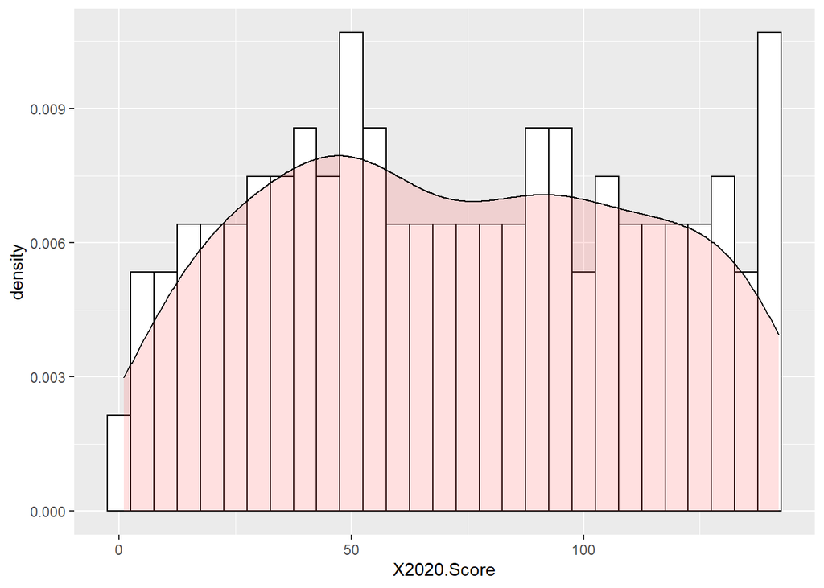

```r
library(ggplot2)
library(moments)
#Histogram overlaid with kernel density curve plotted with more advanced **qqplot()** from **ggplot2()** package

#index2020_data1$X2020.Score <- as.numeric(index2020_data1$X2020.Score)
ggplot(index2020_data1, aes(x=X2020.Score)) +
  geom_histogram(aes(y=..density..),
                 binwidth = 5, colour="black", fill="white") +
  geom_density(alpha=.2, fill="#FF6666") # Overlay with transparent density plot
```

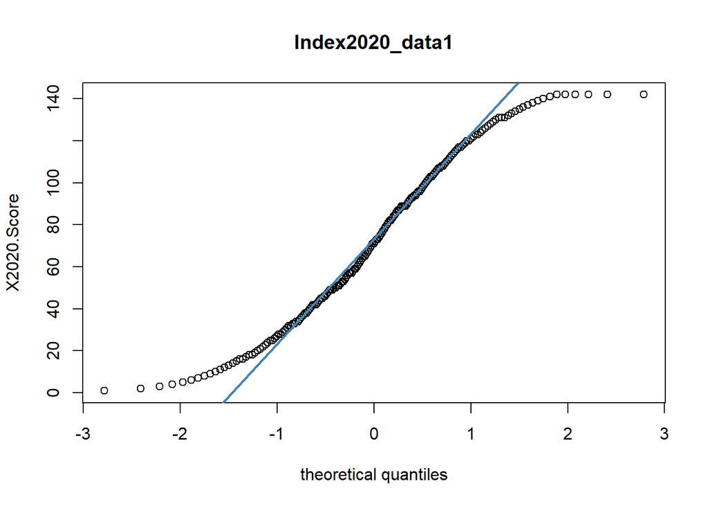

```r
index2020_data1$X2020.Score <- as.numeric(index2020_data1$X2020.Score)
qqnorm(index2020_data1$X2020.Score,xlab="theoretical quantiles", ylab="X2020.Score", main="Index2020_data1")
qqline(index2020_data1$X2020.Score, col = "steelblue", lwd = 2)
```

We now perform a test of normality. The Shapiro-Wilk test of normality is generally more sensitive for sample sizes upto one to two thousand. Since this test have the tendency to be too sensitive, we have plotted other visual representations like ggplot and qqnorm plots with fitted regression lines.

- Null hypothesis $\it{H_{0}}$: Data is normally distributed
- Alternative hypothesis $\it{H_{1}}$: We reject if $p$-value is less than 0.05 (claim)

```r
test_results = shapiro.test(index2020_data1$X2020.Score)
if (test_results$p.value > 0.05)
{
  cat("The distribution can be considered Normal, p-value=", test_results$p.value)
}
test_results
```

```
##
##  Shapiro-Wilk normality test
##
## data:  index2020_data1$X2020.Score
## W = 0.95873, p-value = 2.744e-05
```

> Perform regression analysis over the dataset

We create train and test sets using the SplitRatio.

```r
require(caTools) #loading the library
set.seed(123)

data_split <- sample.split(data.clean$X2020.Score, SplitRatio = 0.8)
data.train <- subset(data.clean, data_split = TRUE)
data.test <- subset(data.clean, data_split = FALSE)
```

On our preliminary analysis, we perform **linear regression** against 2020 scores obtained considering all the other factors in the dataset. This helps us determine the extent to which there could be a linear relationship between the independent variable 2020 Score with the other dependent variables in the dataset as mentioned below.

```r
fit_regression <- lm(X2020.Score ~ Property.Rights+Judical.Effectiveness+Government.Integrity+Tax.Burden+Gov.t.Spending+Fiscal.Health+Business.Freedom+Labor.Freedom+Monetary.Freedom+Trade.Freedom+Investment.Freedom+Financial.Freedom+Tariff.Rate....+Income.Tax.Rate....+Corporate.Tax.Rate....+Tax.Burden...of.GDP+Gov.t.Expenditure...of.GDP+Population..Millions.+GDP..Billions..PPP.+GDP.Growth.Rate....+X5.Year.GDP.Growth.Rate....+GDP.per.Capita..PPP.+Unemployment....+Inflation....+FDI.Inflow..Millions.+Public.Debt....of.GDP.,
                     data = index2020_data1) # get the fit and store to fit_regression object
coefficients(fit_regression) #show results
```

```
##                 (Intercept)             Property.Rights
##               -7.287099e+01                2.098555e-01
##       Judical.Effectiveness        Government.Integrity
##                1.094232e-01                9.804112e-02
##                  Tax.Burden              Gov.t.Spending
##                1.845747e-01                2.194581e-02
##               Fiscal.Health            Business.Freedom
##                1.664260e-01                9.873849e-02
##               Labor.Freedom            Monetary.Freedom
##                8.199246e-02               -1.356437e-02
##               Trade.Freedom          Investment.Freedom
##                1.695946e-01                8.640330e-01
##           Financial.Freedom             Tariff.Rate....
##                6.977120e+00                6.225177e-03
##         Income.Tax.Rate....      Corporate.Tax.Rate....
##                3.472397e-01                1.869146e-01
##         Tax.Burden...of.GDP  Gov.t.Expenditure...of.GDP
##                5.014277e-02               -8.085546e-02
##       Population..Millions.         GDP..Billions..PPP.
##                3.169924e-04                1.638601e-02
##         GDP.Growth.Rate.... X5.Year.GDP.Growth.Rate....
##               -6.286100e-02                9.493824e-03
##        GDP.per.Capita..PPP.            Unemployment....
##               -2.397114e-02               -7.059853e-02
##               Inflation....       FDI.Inflow..Millions.
##               -3.748160e-02                1.710440e-02
##      Public.Debt....of.GDP.
##                1.511326e-03
```

```r
lm_predicted_values = predict(fit_regression,  newdata=data.test)
summary(fit_regression)
```

```
##
## Call:
## lm(formula = X2020.Score ~ Property.Rights + Judical.Effectiveness +
##     Government.Integrity + Tax.Burden + Gov.t.Spending + Fiscal.Health +
##     Business.Freedom + Labor.Freedom + Monetary.Freedom + Trade.Freedom +
##     Investment.Freedom + Financial.Freedom + Tariff.Rate.... +
##     Income.Tax.Rate.... + Corporate.Tax.Rate.... + Tax.Burden...of.GDP +
##     Gov.t.Expenditure...of.GDP + Population..Millions. + GDP..Billions..PPP. +
##     GDP.Growth.Rate.... + X5.Year.GDP.Growth.Rate.... + GDP.per.Capita..PPP. +
##     Unemployment.... + Inflation.... + FDI.Inflow..Millions. +
##     Public.Debt....of.GDP., data = index2020_data1)
##
## Residuals:
##     Min      1Q  Median      3Q     Max
## -37.027  -6.084   1.197   5.662  40.806
##
## Coefficients:
##                               Estimate Std. Error t value Pr(>|t|)
## (Intercept)                 -72.870992   9.274896  -7.857 5.56e-13 ***
## Property.Rights               0.209856   0.075054   2.796 0.005811 **
## Judical.Effectiveness         0.109423   0.051627   2.119 0.035602 *
## Government.Integrity          0.098041   0.093434   1.049 0.295629
## Tax.Burden                    0.184575   0.044444   4.153 5.34e-05 ***
## Gov.t.Spending                0.021946   0.044995   0.488 0.626404
## Fiscal.Health                 0.166426   0.022985   7.241 1.80e-11 ***
## Business.Freedom              0.098739   0.042123   2.344 0.020313 *
## Labor.Freedom                 0.081992   0.025480   3.218 0.001565 **
## Monetary.Freedom             -0.013564   0.038901  -0.349 0.727781
## Trade.Freedom                 0.169595   0.046456   3.651 0.000354 ***
## Investment.Freedom            0.864033   0.362468   2.384 0.018317 *
## Financial.Freedom             6.977120   0.781509   8.928 1.01e-15 ***
## Tariff.Rate....               0.006225   0.037560   0.166 0.868574
## Income.Tax.Rate....           0.347240   0.121170   2.866 0.004724 **
## Corporate.Tax.Rate....        0.186915   0.125254   1.492 0.137607
## Tax.Burden...of.GDP           0.050143   0.025937   1.933 0.054978 .
## Gov.t.Expenditure...of.GDP   -0.080855   0.048731  -1.659 0.099045 .
## Population..Millions.         0.000317   0.007077   0.045 0.964328
## GDP..Billions..PPP.           0.016386   0.019308   0.849 0.397354
## GDP.Growth.Rate....          -0.062861   0.082126  -0.765 0.445154
## X5.Year.GDP.Growth.Rate....   0.009494   0.084311   0.113 0.910486
## GDP.per.Capita..PPP.         -0.023971   0.019425  -1.234 0.219010
## Unemployment....             -0.070598   0.180673  -0.391 0.696503
## Inflation....                -0.037482   0.053990  -0.694 0.488549
## FDI.Inflow..Millions.         0.017104   0.017961   0.952 0.342385
## Public.Debt....of.GDP.        0.001511   0.022641   0.067 0.946862
## ---
## Signif. codes:  0 '***' 0.001 '**' 0.01 '*' 0.05 '.' 0.1 ' ' 1
##
## Residual standard error: 12.37 on 159 degrees of freedom
##   (1 observation deleted due to missingness)
## Multiple R-squared:  0.9191, Adjusted R-squared:  0.9058
## F-statistic: 69.45 on 26 and 159 DF,  p-value: < 2.2e-16
```

From the regression analysis performed, we obtain 91.91% variance in economic freedom in countries which is explained by the independent variables.

Our second step is to perform **principal component analysis** which is a useful technique for exploratory data analysis allowing us to better visualize the variation present in the data with many variables what contribute to 2020 scores of economic freedom for all the countries listed. Since, our data set is a large one, for many variables that we have in our sample we can reduce the dimensionality and regress to find out the predicted errors comparing it with linear regression.

We do the above mentioned to find out the variances obtained to try out methods that further help improve create better predictive models.

```r
head(data.clean, 5)
```

```
##   X CountryID Country.Name     WEBNAME                       Region World.Rank
## 1 1         1  Afghanistan Afghanistan                 Asia-Pacific         43
## 2 2         2      Albania     Albania                       Europe        135
## 3 3         3      Algeria     Algeria Middle East and North Africa         79
## 4 4         4       Angola      Angola           Sub-Saharan Africa         63
## 5 5         5    Argentina   Argentina                     Americas         57
##   Region.Rank X2020.Score Property.Rights Judical.Effectiveness
## 1          43          38              39                    20
## 2         135          94              58                    30
## 3          79          13              17                    35
## 4          63          25              16                     5
## 5          57          29              45                    67
##   Government.Integrity Tax.Burden Gov.t.Spending Fiscal.Health Business.Freedom
## 1                   18        134            111           158               43
## 2                   47        115             97            99               78
```

[output cut: 39 more lines]

```r
data.pca <- data.clean[-c(1,2,3,4,5,9,21,26)]
data.pca2 <- prcomp(data.pca, scale. = TRUE)
summary(data.pca2)
```

```
## Importance of components:
##                           PC1    PC2     PC3     PC4     PC5     PC6     PC7
## Standard deviation     2.5895 1.7135 1.54180 1.31822 1.16293 1.13282 1.10447
## Proportion of Variance 0.2484 0.1087 0.08804 0.06436 0.05009 0.04753 0.04518
## Cumulative Proportion  0.2484 0.3571 0.44515 0.50951 0.55960 0.60713 0.65231
##                            PC8    PC9    PC10    PC11    PC12    PC13    PC14
## Standard deviation     1.09068 1.0183 0.99602 0.90813 0.89815 0.85182 0.76051
## Proportion of Variance 0.04406 0.0384 0.03674 0.03054 0.02988 0.02687 0.02142
## Cumulative Proportion  0.69637 0.7348 0.77151 0.80206 0.83193 0.85881 0.88023
##                           PC15    PC16    PC17    PC18    PC19   PC20    PC21
## Standard deviation     0.73704 0.70433 0.64618 0.59287 0.57110 0.5170 0.48280
## Proportion of Variance 0.02012 0.01837 0.01546 0.01302 0.01208 0.0099 0.00863
## Cumulative Proportion  0.90035 0.91872 0.93419 0.94721 0.95928 0.9692 0.97782
##                          PC22    PC23    PC24    PC25    PC26      PC27
## Standard deviation     0.4316 0.41095 0.33051 0.27709 0.24043 1.795e-16
## Proportion of Variance 0.0069 0.00625 0.00405 0.00284 0.00214 0.000e+00
## Cumulative Proportion  0.9847 0.99097 0.99502 0.99786 1.00000 1.000e+00
```

```r
library(factoextra)
```

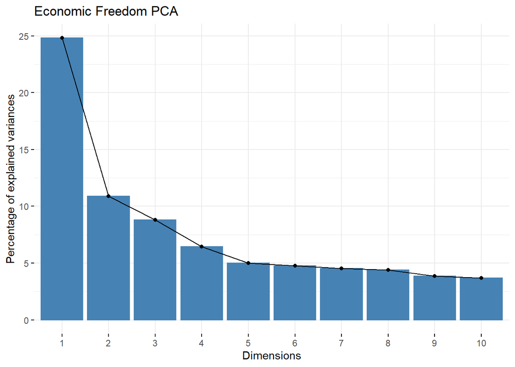

```r
fviz_eig(data.pca2, main = "Economic Freedom PCA")
```

```r
suppressPackageStartupMessages(library(pls)) # suppress warning for the demo sake
```

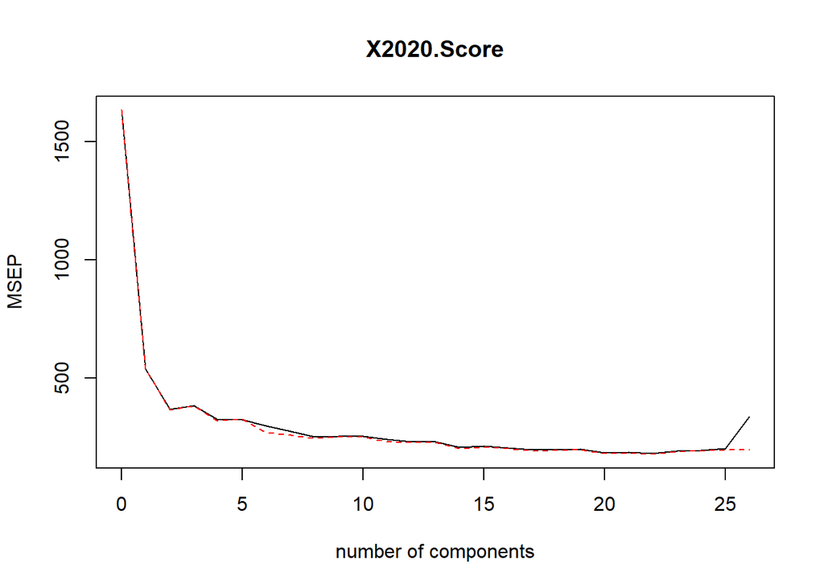

```r
set.seed (1000) # seed random generator
pcr_model <- pcr(X2020.Score~., data = data.pca, scale = TRUE, validation = "CV")

#Plot the cross-validation mean square errors as a function of component number used
validationplot(pcr_model, val.type = "MSEP")
```

From the cross-validation plot we can infer that the model has a little shift towards variance.

```r
pcr_predict2 <- predict(pcr_model, data.test, ncomp = 3)
pcr_predict3 <- predict(pcr_model, data.test, ncomp = 3)
cat("Prediction error of PCR for 2 coefficients = ", mean((pcr_predict2 - data.test$X2020.Score)^2), "\n")
```

```
## Prediction error of PCR for 2 coefficients =  359.1456
```

```r
cat("Prediction error of PCR for 3 coefficients = ", mean((pcr_predict3 - data.test$X2020.Score)^2), "\n")
```

```
## Prediction error of PCR for 3 coefficients =  359.1456
```

```r
cat("Prediction error of Linear Regression =", mean((lm_predicted_values - data.test$X2020.Score)^2))
```

```
## Prediction error of Linear Regression = 130.7452
```

We obtain a lower prediction error using the linear regression. Regression of the principal component does not consider the response variable when determining which key components to remove. The decision to remove components would only be based on the size of the feature variance.

Using **Ridge Regression** in this scenario, a diagonal matrix is added to the X’X matrix so that it becomes better conditioned.

```r
library(Matrix)
library(glmnet)
x.tr <- model.matrix(X2020.Score~., data = data.train)[,-1]
y.tr <- data.train$X2020.Score
x.val <- model.matrix(X2020.Score~., data = data.test)[,-1]
y.val <- data.test$X2020.Score

set.seed(700)
rr.cv <- cv.glmnet(x.tr, y.tr, alpha = 0)
rr.cv
```

```
##
## Call:  cv.glmnet(x = x.tr, y = y.tr, alpha = 0)
##
## Measure: Mean-Squared Error
##
##     Lambda Measure    SE Nonzero
## min  330.5   839.1 52.86     593
## 1se  398.1   891.5 55.02     593
```

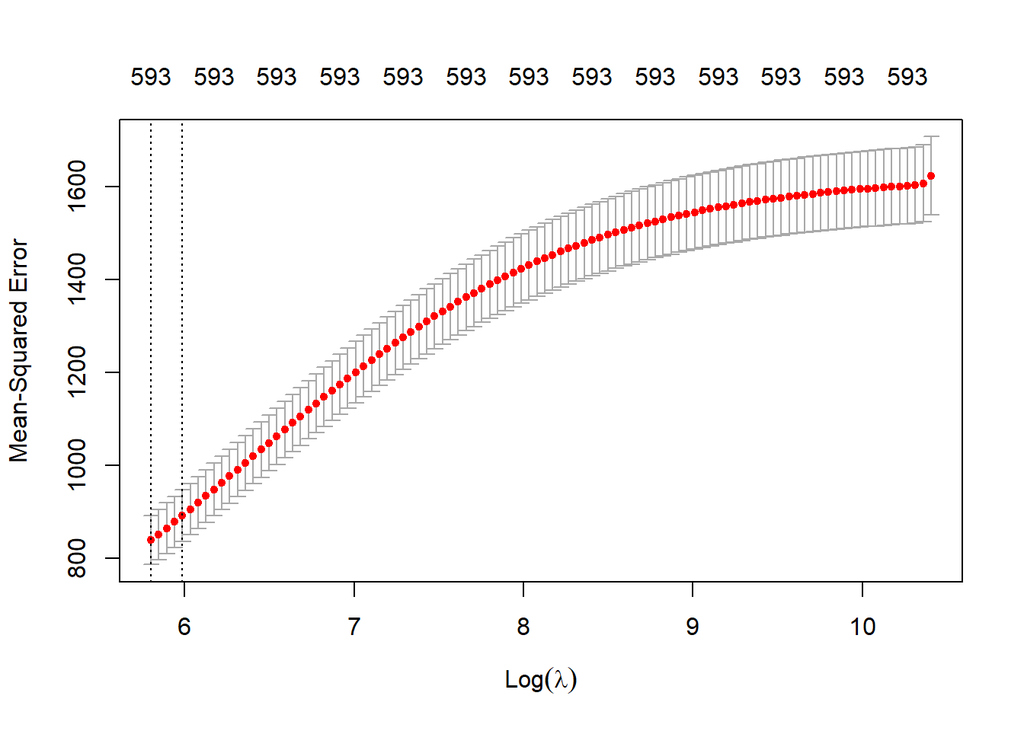

```r
plot(rr.cv)
```

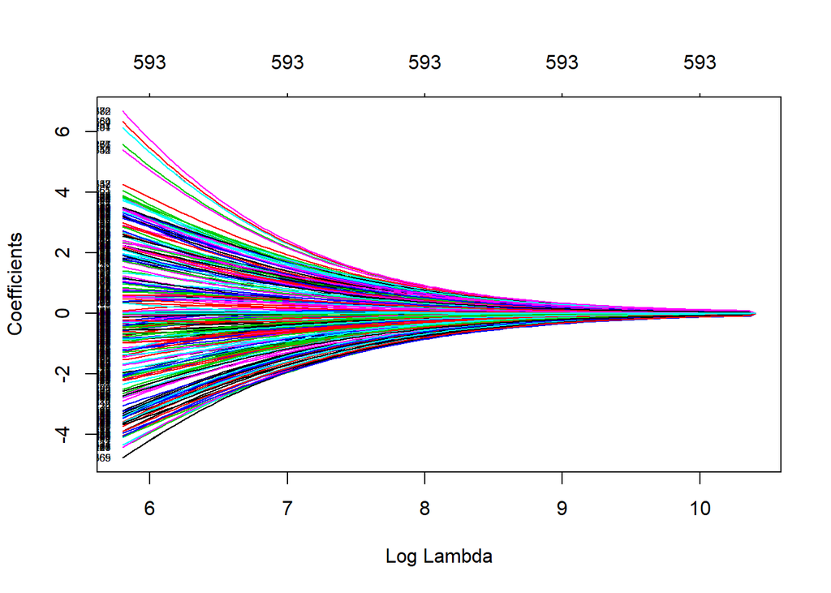

```r
rr.bestlam <- rr.cv$lambda.min
rr.goodlam <- rr.cv$lambda.1se

# predict validation set using best lambda and calculate RMSE
rr.fit <- glmnet(x.tr, y.tr, alpha = 0)
plot(rr.fit, xvar = "lambda", label = TRUE)
```

Since, the ridge regression enforces the coefficients to be shrunk to zero, hence minimizing their impact on the trained model. Using the method glmnet to map the direction of each of the variable coefficients of x against log lambda. The graph shows at which point each coefficient is shrinking to null.

> Further Analysis

We create boxplots for the most important variables to compare their variations.

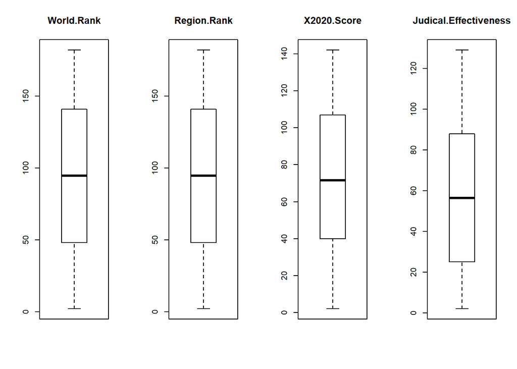

```r
x <- data.pca[,1:4]
y <- data.pca[,5]
par(mfrow=c(1,4))
  for(i in 1:4)
    boxplot(x[,i], main=names(data.pca)[i])
```

> Test Harness using 10-fold cross validation

```r
library(caret)
#Run algorithms using 10-fold cross validation
control <- trainControl(method = "cv", number = 10)
metric <- "RMSE"
```

Build models - We get an idea from the plots that some of the classes are partially linearly separable in some dimensions, so we are expecting generally good results.

-Classification and Regression Trees (CART).  
-k-Nearest Neighbors (kNN).  
-Support Vector Machines (SVM) with a linear kernel.  
-Random Forest (RF)

```r
#install.packages('e1071', dependencies=TRUE)
n <- names(data.pca$X2020.Score)
f <- as.formula(paste("X2020.Score~.", paste(n[!n %in% "y"], collapse = " + ")))
set.seed(7)

#nonlinear algorithms
set.seed(7)
fit.cart <- train(X2020.Score~., data = data.pca, method = "rpart", metric = metric, trControl = control)
#kNN
set.seed(7)
fit.knn <- train(X2020.Score~., data = data.pca, method = "knn", metric = metric, trControl = control)

#advanced algorithms
#SVM
set.seed(7)
fit.svm <- train(X2020.Score~., data = data.pca, method = "svmRadial", metric = metric, trControl = control)

#Random forest
set.seed(7)
fit.rf <- train(X2020.Score~., data = data.pca, method = "rf", metric = metric, trControl = control)
```

We now have 4 models and accuracy estimations for each. We need to compare the models to each other and select the most accurate.

We can report on the regression metrics of each model by first creating a list of the created models and using the summary function.

```r
results <- resamples(list(cart = fit.cart, knn = fit.knn, svm = fit.svm, rf = fit.rf))
summary(results)
```

```
##
## Call:
## summary.resamples(object = results)
##
## Models: cart, knn, svm, rf
## Number of resamples: 10
##
## MAE
##           Min.   1st Qu.    Median      Mean   3rd Qu.      Max. NA's
## cart 14.315953 16.317298 16.895870 16.993377 17.508940 20.666114    0
## knn   8.810526 12.178333 13.448297 13.272174 14.326316 16.144444    0
## svm   6.011538  7.220189  8.489469  8.784988  9.862056 13.508191    0
## rf    4.598784  5.122673  5.823890  5.669701  6.202593  6.536327    0
##
## RMSE
##           Min.   1st Qu.    Median      Mean  3rd Qu.     Max. NA's
## cart 17.522600 18.735303 20.487820 21.164261 21.94374 28.39800    0
## knn  10.176443 15.564053 16.423528 17.555694 21.24066 23.08944    0
## svm   7.767835  9.193964 11.199721 13.387713 16.35971 25.87075    0
## rf    6.071916  8.214564  9.098178  9.335904 10.55034 13.11052    0
##
## Rsquared
##           Min.   1st Qu.    Median      Mean   3rd Qu.      Max. NA's
## cart 0.5418365 0.7034116 0.7530686 0.7351566 0.7860766 0.8647139    0
## knn  0.6487027 0.7767097 0.8535811 0.8306945 0.8940969 0.9413823    0
## svm  0.5890187 0.8709176 0.9337943 0.8840185 0.9553616 0.9627303    0
## rf   0.9062081 0.9535890 0.9604511 0.9568192 0.9674053 0.9844385    0
```

We can also create a plot of the model evaluation results and compare the spread and the mean accuracy of each model. There is a population of accuracy measures for each algorithm because each algorithm was evaluated 10 times (10 fold cross validation).

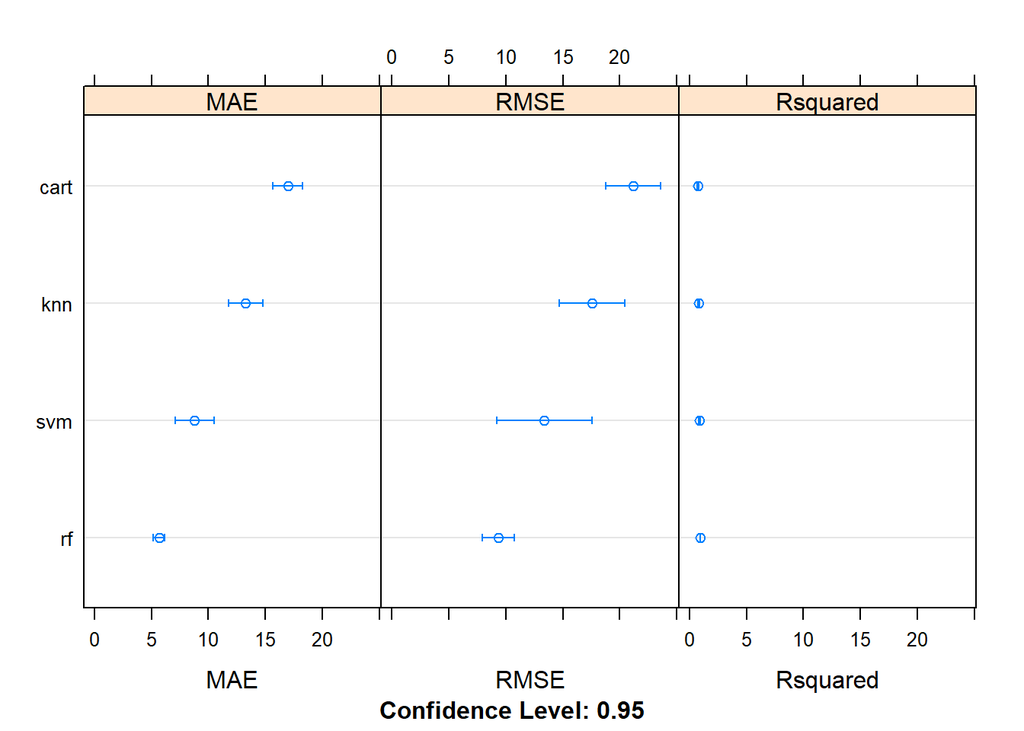

```r
dotplot(results)
```

If there is any one statistic that normally takes precedence over the others, it is the root mean squared error (RMSE), which is the square root of the mean squared error. When it is adjusted for the degrees of freedom for error (sample size minus number of model coefficients), it is known as the standard error of the regression or standard error of the estimate in regression analysis.

This is the statistic whose value is minimized during the parameter estimation process, and it is the statistic that determines the width of the confidence intervals for predictions.

The lowest RMSE that the model here shows is the Random Forest measure. Random Forest gives you probability of belonging to class whereas SVM gives you distance to the boundary, you still need to convert it to probability somehow if you need probability.

Our decision would be to use Support Vector Machine (SVM) as a base to start our analysis upon. There are still many questions that do not have any output variables in the dataset which would require some unsupervised techniques such as k-means or DBSCAN clusterig techniques.

> Importing Data Set with variable ‘Status’

The variable Status is computed using Excel which takes X2020.Scores attribute (containing dependent variables from Economic Freedom indices) and uses this to present four categories - Excellent, Good, Below Average, Poor.

```r
index2020_category <- read.csv("C:/Users/SwetaMankala/Desktop/Intermediate Analytics/index2020_data2.csv", stringsAsFactors = FALSE)

#to view the initial portions of the dataset
head(index2020_category, 5)
```

```
##   X CountryID Country.Name     WEBNAME                       Region World.Rank
## 1 1         1  Afghanistan Afghanistan                 Asia-Pacific         43
## 2 2         2      Albania     Albania                       Europe        135
## 3 3         3      Algeria     Algeria Middle East and North Africa         79
## 4 4         4       Angola      Angola           Sub-Saharan Africa         63
## 5 5         5    Argentina   Argentina                     Americas         57
##   Region.Rank X2020.Score        Status Property.Rights Judical.Effectiveness
## 1          43          38          Good              39                    20
## 2         135          94          Good              58                    30
## 3          79          13 Below Average              17                    35
## 4          63          25          Good              16                     5
## 5          57          29          Good              45                    67
##   Government.Integrity Tax.Burden Gov.t.Spending Fiscal.Health Business.Freedom
## 1                   18        134            111           158               43
## 2                   47        115             97            99               78
```

[output cut: 39 more lines]

We remove the factor variables and clean the dataset removing empty values.

```r
dataNumeric <- index2020_category[-c(3,4,5)]
dataNumeric <- na.omit(dataNumeric)
```

We have split our dataset into train and test sets.

```r
index <- 1:nrow(dataNumeric)
testIndex <- sample(index, trunc(length(index)/3))
testset <- dataNumeric[testIndex,]
trainset <- dataNumeric[-testIndex,]
```

```r
trainset
```

```
##       X CountryID World.Rank Region.Rank X2020.Score        Status
## 1     1         1         43          43          38          Good
## 2     2         2        135         135          94          Good
## 3     3         3         79          79          13 Below Average
## 6     6         6        110         110         113          Good
## 8     8         8        104         104         117          Good
## 9     9         9        121         121         105          Good
## 11   11        11        142         142          90          Good
## 12   12        12         28          28          48          Good
## 14   14        14        169         169          71          Good
## 16   16        16         16          16          53          Good
## 18   18        18        166         166          73          Good
## 19   19        19         86          86           7 Below Average
## 20   20        20        163         163          76          Good
## 21   21        21        117         117         108          Good
```

[output cut: 1235 more lines]

The plot below shows a general composition of how the categories present here has been split according to our X2020.Score variable. The region consisting of the ‘good’ status seems to be dominating which is a good indication of the economy.

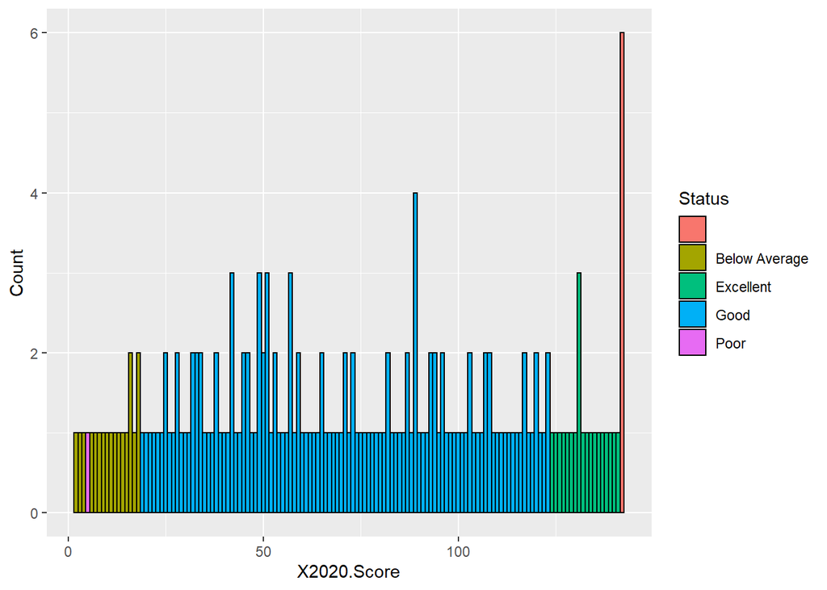

```r
ggplot(dataNumeric) + aes(x=as.numeric(X2020.Score), group=Status, fill=Status) + labs(x="X2020.Score", y="Count") + geom_histogram(binwidth=1, color='black')
```

The below graph shows a scatterplot of the data indices w.r.t the variables 2020 Scores and GDP..Billions..PPP.

```r
library(caret)
library(e1071)
library(kernlab)
```

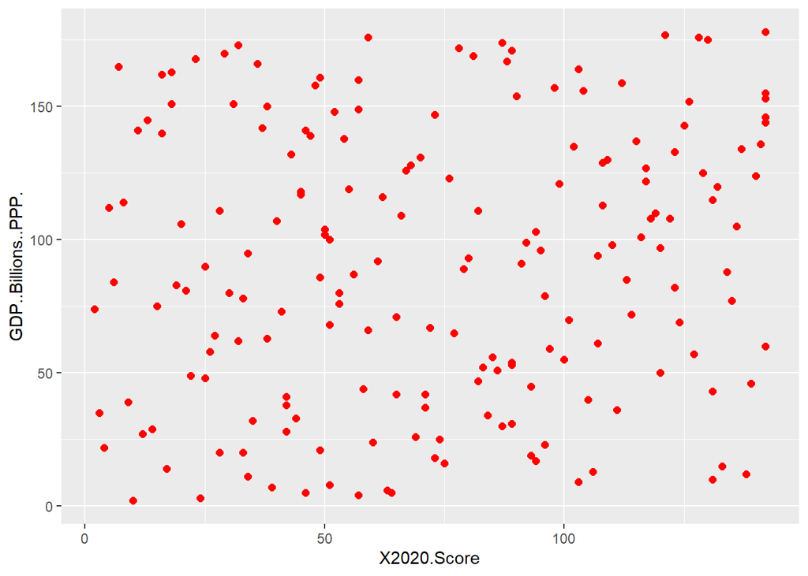

```r
library(RColorBrewer)
library(ggplot2)

ggplot(data = dataNumeric, aes(x = X2020.Score, y = GDP..Billions..PPP., colour = "pink")) +
  geom_point(size = 2) +
  scale_color_manual(values=c("red")) +
  theme(legend.position = "none")
```

> Exploration of Data

**Support Vector Machine** is a supervised machine learning model with associated learning algorithms that analyzes data used for classification and regression analysis. In this algorithm, each data item is plotted as a point in n-dimensional space (where n is the number of features), with each value of each feature being the value of a particular coordinate.

In the Support Vector Machine algorithm, what we are trying to do here is basically trying to decide a decision boundary at a distance from the original hyper plane such that data points closest to the hyper plane or the support vectors. In simple terms that we are going to take only those those points which have least error rate. Thus giving us a better fitting model.

```r
library(caret)
library(e1071)
library(kernlab)

svmfit <- svm(dataNumeric$X2020.Score ~ dataNumeric$GDP..Billions..PPP., data = dataNumeric, kernel = "radial")
print(svmfit)
```

```
##
## Call:
## svm(formula = dataNumeric$X2020.Score ~ dataNumeric$GDP..Billions..PPP.,
##     data = dataNumeric, kernel = "radial")
##
##
## Parameters:
##    SVM-Type:  eps-regression
##  SVM-Kernel:  radial
##        cost:  1
##       gamma:  1
##     epsilon:  0.1
##
##
## Number of Support Vectors:  179
```

```r
predictModel <- predict(svmfit, dataNumeric)

resultSVM <- table(pred = predictModel, true = dataNumeric[, 6])
resultSVM
```

[output not shown]

[output cut: 124 more lines]

```
##   80.3762054503679 0             0         0    1    0
##   80.3873411574923 0             0         0    2    0
##   80.5125275124087 0             0         1    0    0
##   80.5202890210046 0             0         0    0    1
##   80.6195126246711 0             0         0    1    0
##   80.6246540133053 0             0         0    1    0
##   80.6965316323649 0             0         0    1    0
##   80.6996317306815 0             1         0    0    0
##   80.7431623547678 0             0         0    1    0
##   80.7446133925682 0             0         1    0    0
##   80.7591912038006 0             0         0    1    0
##   80.9291585234443 0             0         1    0    0
##   81.6490793913321 0             0         1    1    0
##   82.3789614927264 0             0         0    1    0
##   83.1162145897096 1             0         0    0    0
```

```r
accuracySVM <- sum(diag(resultSVM))/sum(resultSVM)

cat('The accuracy of SVM radial model is', round(accuracySVM*100, 2), '%\n')
```

```
## The accuracy of SVM radial model is 1.08 %
```

The accuracy here shows a values of 1.08% which is very low. The predictions w.r.t the categories here show us the kind of values that gets computed.

The below given is a method implemented to give SVM Linear Kernel predictions.

Before we train our model, we’ll first implement the trainControl() method. This will control all the computational overheads so that we can use the train() function provided by the caret package.

The trainControl() method takes 3 parameters -

- “method” parameter defines the resampling method, in this demo we’ll be using the repeatedcv or the repeated cross-validation method.
- next parameter is the “number”, this basically holds the number of resampling iterations.
- “repeats” parameter contains the sets to compute for our repeated cross-validation. We are using setting number =10 and repeats =3

We are passing 2 values in our “pre-process” parameter “center” & “scale”. These two help for centering and scaling the data. After pre-processing, these convert our training data with mean value as approximately “0” and standard deviation as “1”. The “tuneLength” parameter holds an integer value. This is for tuning our algorithm.

We build our SVM Classifier as given below selecting the value C (cost) in the Linear classifier. This can be done by inputting values in grid search.

We are going to put some values of C using expand.grid() into “grid” dataframe. Next step is to use this dataframe for testing our classifier at specific C values. It needs to be put in train() method with tuneGrid parameter.

```r
trControl <- trainControl(method = "repeatedcv", number = 10, repeats = 3)
grid <- expand.grid(C = c(0,0.01, 0.05, 0.1, 0.25, 0.5, 0.75, 1, 1.25, 1.5, 1.75, 2,5))
svm_Linear <- train(X2020.Score~., data = trainset, method = "svmLinear",
                    trControl = trControl, preProcess = c("center", "scale"),
                    tuneLength = 10, tuneGrid = grid)
svm_Linear
```

```
## Support Vector Machines with Linear Kernel
##
## 124 samples
##  32 predictor
##
## Pre-processing: centered (156), scaled (156)
## Resampling: Cross-Validated (10 fold, repeated 3 times)
## Summary of sample sizes: 111, 111, 111, 112, 112, 111, ...
## Resampling results across tuning parameters:
##
##   C     RMSE      Rsquared   MAE
##   0.00       NaN        NaN       NaN
##   0.01  34.51880  0.7968429  29.39426
##   0.05  21.04652  0.8376604  16.47577
##   0.10  16.82460  0.8507020  12.13256
##   0.25  15.53932  0.8730419  11.33966
##   0.50  15.05846  0.8885232  11.45215
##   0.75  15.02768  0.8894083  11.44512
##   1.00  15.02768  0.8894083  11.44512
##   1.25  15.02768  0.8894083  11.44512
##   1.50  15.02768  0.8894083  11.44512
##   1.75  15.02768  0.8894083  11.44512
##   2.00  15.02768  0.8894083  11.44512
##   5.00  15.02768  0.8894083  11.44512
##
## RMSE was used to select the optimal model using the smallest value.
## The final value used for the model was C = 0.75.
```

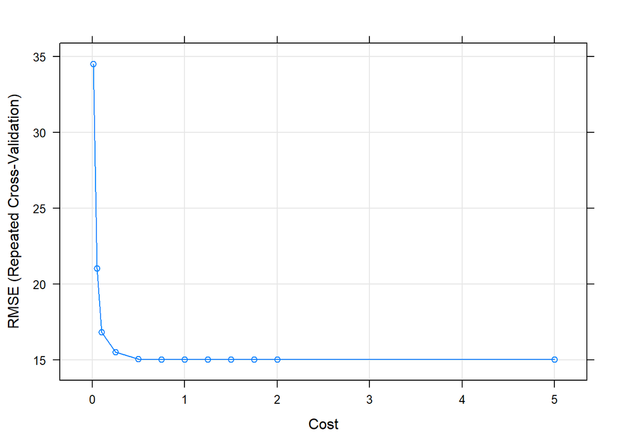

```r
plot(svm_Linear)
```

Now, our model is trained with C value as 0.75. We can find out the predictions and accuracy of the model.

```r
test_pred <- predict(svm_Linear, newdata = trainset)
result <- table(predict = test_pred, truth = trainset$X2020.Score)
accuracySL <- sum(diag(result))/sum(result)
cat('The accuracy of SVM linear model is', round(accuracySL*100, 2), '%\n')
```

```
## The accuracy of SVM linear model is 9.68 %
```

Our output shows the accuracy as given above letting us know the improvement of SVM Radial to SVM Linear method. The graph is another visualization of the cost of SVM linear kernel giving its best accuracy at 0.75.

The below given method is another implementation of the SVM Linear Kernel wherein we use a C-Classification type method to find the values.

```r
library(e1071)

dataNumeric$Status <- as.character(dataNumeric$Status)


#if (NA) {}
#plot(predModel$X2020.Score, col = "blue")
svm.model <- svm(X2020.Score ~ GDP..Billions..PPP.,
                 data = trainset, cost = 100, gamma = 0.0001, type = 'C', kernel = 'linear')

print(svm.model)
```

```
##
## Call:
## svm(formula = X2020.Score ~ GDP..Billions..PPP., data = trainset,
##     cost = 100, gamma = 1e-04, type = "C", kernel = "linear")
##
##
## Parameters:
##    SVM-Type:  C-classification
##  SVM-Kernel:  linear
##        cost:  100
##
## Number of Support Vectors:  124
```

```r
svm.pred <- predict(svm.model, trainset)

resultSL <- table(predict = svm.pred, truth = trainset$X2020.Score)
accuracy <- sum(diag(resultSL))/sum(resultSL)

cat('The accuracy of SVM linear model is', round(accuracy*100, 2), '%\n')
```

```
## The accuracy of SVM linear model is 6.45 %
```

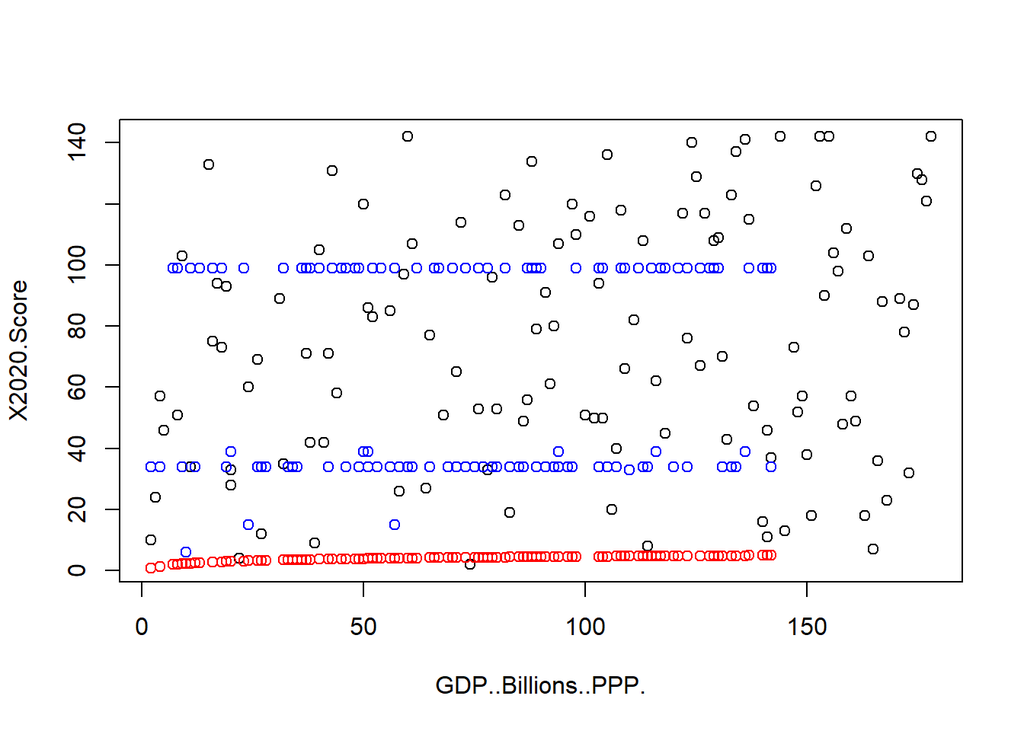

```r
x <- trainset$X2020.Score
plot(X2020.Score ~ GDP..Billions..PPP., data = trainset)
points(x, log(x), col = 2)
points(x, svm.pred, col = 4)
```

```r
#Calculate the parameters of SVR model
W = t(svm.model$coefs) %*% svm.model$SV
W
```

```
##              [,1]
##  [1,] -2069.52752
##  [2,]  4011.07356
##  [3,] -1901.28530
##  [4,]   578.93804
##  [5,] -1685.78066
##  [6,]  2007.93214
##  [7,] -1682.44907
##  [8,] -2206.79847
##  [9,]  2264.79599
## [10,]  1062.00938
## [11,]  1677.61274
## [12,] -2000.78303
## [13,]  -768.91985
## [14,] -2069.53948
```

[output cut: 84 more lines]

```r
#Find value of b
b = svm.model$rho
b
```

[output not shown]

[output cut: 956 more lines]

We calculate the above values as given.

The is another plot of our categories represented with different variables.

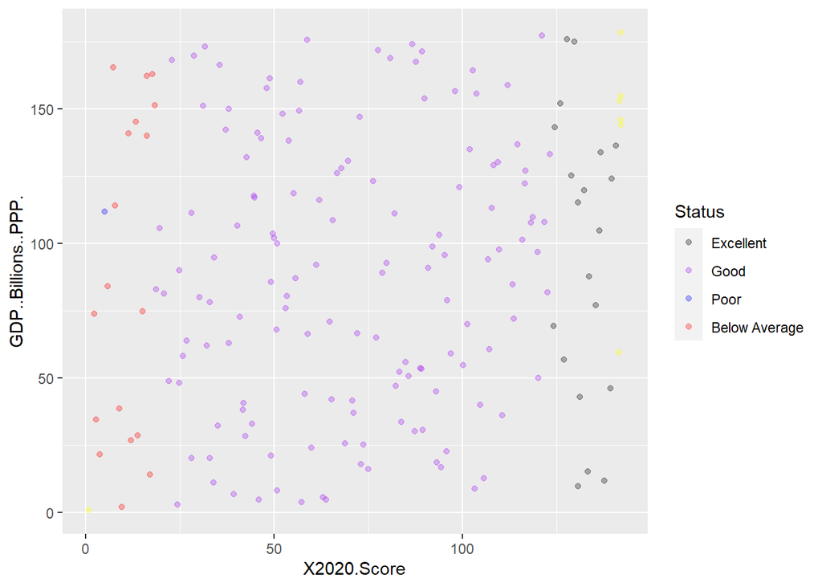

```r
rfData <- read.csv("C:/Users/SwetaMankala/Desktop/Intermediate Analytics/index2020_data2.csv")

p = ggplot(rfData,aes(x=X2020.Score,
                    y=GDP..Billions..PPP.,
                    color=Status))
p + geom_jitter(alpha=0.3) +
  scale_color_manual(breaks = c('Excellent', 'Good', 'Poor', 'Below Average'),
                     values=c('yellow','red', 'black', 'purple', 'blue'))
```

We can see as given in the plot that countries having excellent economy has its data values plotted in ‘black’. This includes countries such as Canada, Denmark, Hong Kong Iceland etc.

The countries with poor economy has its data values plotted in ‘blue’ which do not represent a lot of countries. As given in our dataset, we have only one country which is North Korea that has a poor economy.

The below given is the splitting of the dataset for cross-validation.

```r
#Create data for training
sample.ind = sample(2,
                     nrow(rfData),
                     replace = T,
                     prob = c(0.05,0.95))
data.dev = rfData[sample.ind==1,]
data.val = rfData[sample.ind==2,]

cat("Original Data-\n")
```

```
## Original Data-
```

```r
table(rfData$Status)/nrow(rfData)
```

```
##
##               Below Average     Excellent          Good          Poor
##   0.037433155   0.096256684   0.106951872   0.754010695   0.005347594
```

```r
cat("\n")
```

```r
cat("Training Data-\n")
```

```
## Training Data-
```

```r
table(data.dev$Status)/nrow(rfData)
```

```
##
##               Below Average     Excellent          Good          Poor
##   0.000000000   0.005347594   0.005347594   0.048128342   0.000000000
```

```r
cat("\n")
```

```r
cat("Testing Data-\n")
```

```
## Testing Data-
```

```r
table(data.val$Status)/nrow(rfData)
```

```
##
##               Below Average     Excellent          Good          Poor
##   0.037433155   0.090909091   0.101604278   0.705882353   0.005347594
```

> Conclusion

In conclusion, throughout the research we analyzed the relationship between variables from 4 broad category:

1.Rule of Law (property rights, government integrity, judicial effectiveness)  
2.Government Size (government spending, tax burden, fiscal health)  
3.Regulatory Efficiency (business freedom, labor freedom, monetary freedom)  
4.Open Markets (trade freedom, investment freedom, financial freedom)

We also analysed the economic freedom of the countries.

> Risk Analysis and Mitigation

One of the primary goals of our research was to find the main factors among all independent variables who impact more on economic freedom index of countries whose status is excellent. However, throughout the analysis, we come to conclusion that there is no any specific factors, which is applicable to all economically most free countries. That is why we are not able to give an advice to poor countries to improve specific feature of economic freedom. Instead, our advice is to improve their economic freedom as much as they can no matter which feature of economic freedom to focus.

> Appendix

Fit Random Forest Model -

> References

-Carlsson, F. and Lundstrom, S. (2002). Economic Freedom and Growth: Decomposing the Effects. Public Choice, 112(¾):335-344.  
-Economic Freedom of the World. (2019, September 12). Retrieved from https://www.cato.org/economic-freedom-world  
-Heritage Foundation. (2019). Index of Economic Freedom. Available at www.heritage.org/index. uIslam, S. (1996). Economic Freedom, Per Capita Income and Economic Growth. Applied Economics Letters, 3(9):595–597  
-Razmi, M. J. and Refaei, R. (2013). The Effect of Trade Openness and Economic Freedom on Economic Growth: The Case of Middle East and East Asian Countries. International Journal of Economic and Financial Issues, 3(2):376-385.